# Reproducible Research Project

This is my firstR markdown file

Loading and preprocessing the data

Download, unzip and load data into data frame data.

```r
activity<- read.csv("activity.csv")
```

A brief description of the dataset

```r
head(activity)
```

```
##   steps       date interval
## 1    NA 2012-10-01        0
## 2    NA 2012-10-01        5
## 3    NA 2012-10-01       10
## 4    NA 2012-10-01       15
## 5    NA 2012-10-01       20
## 6    NA 2012-10-01       25
```

```r
dim(activity)
```

```
## [1] 17568     3
```

```r
str(activity)
```

```
## 'data.frame':    17568 obs. of  3 variables:
##  $ steps   : int  NA NA NA NA NA NA NA NA NA NA ...
##  $ date    : Factor w/ 61 levels "2012-10-01","2012-10-02",..: 1 1 1 1 1 1 1 1 1 1 ...
##  $ interval: int  0 5 10 15 20 25 30 35 40 45 ...
```

```r
summary(activity)
```

```
##      steps                date          interval
##  Min.   :  0.00   2012-10-01:  288   Min.   :   0.0
##  1st Qu.:  0.00   2012-10-02:  288   1st Qu.: 588.8
##  Median :  0.00   2012-10-03:  288   Median :1177.5
##  Mean   : 37.38   2012-10-04:  288   Mean   :1177.5
##  3rd Qu.: 12.00   2012-10-05:  288   3rd Qu.:1766.2
##  Max.   :806.00   2012-10-06:  288   Max.   :2355.0
##  NA's   :2304     (Other)   :15840
```

# What is mean total number of steps taken per day?

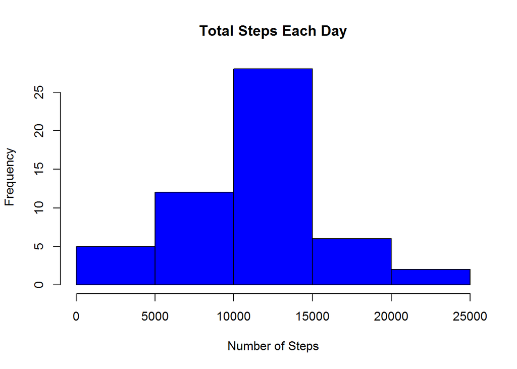

```r
steps_per_day <- aggregate(steps ~ date, activity, sum)
hist(steps_per_day$steps, main = paste("Total Steps Each Day"), col="blue", xlab="Number of Steps")
```

```r
rmean <- mean(steps_per_day$steps)
rmean
```

```
## [1] 10766.19
```

```r
rmedian <- median(steps_per_day$steps)
rmean
```

```
## [1] 10766.19
```

# What is the average daily activity pattern?

Calculate average steps for each interval for all days. Plot the Average Number Steps per Day by Interval. Find interval with most average steps.

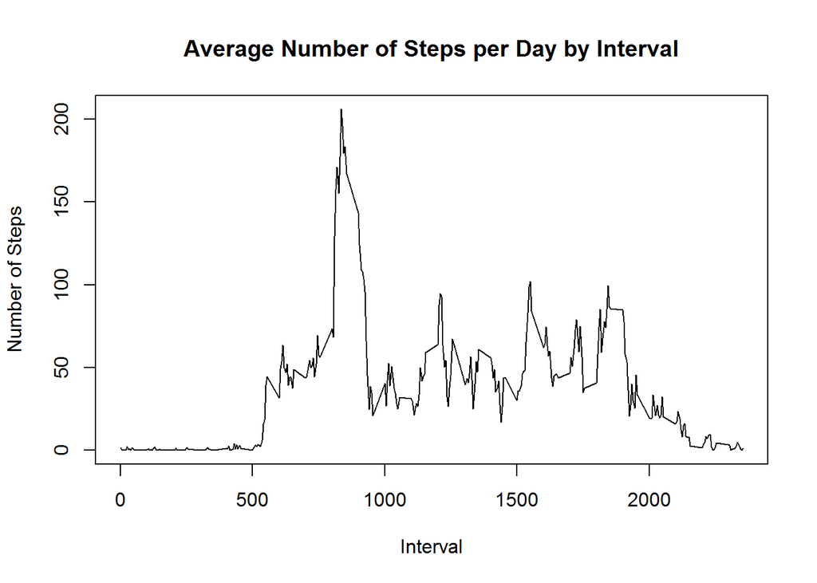

```r
steps_per_interval <- aggregate(steps ~ interval, activity, mean)
plot(steps_per_interval$interval,steps_per_interval$steps, type="l", xlab="Interval", ylab="Number of Steps",main="Average Number of Steps per Day by Interval")
```

```r
library(stats)
```

```r
max_interval <- steps_per_interval[which.max(steps_per_interval$steps),1]
max_interval
```

```
## [1] 835
```

# Impute missing values

Compare imputed to non-imputed data.

Missing data needed to be imputed. Only a simple imputation approach was required for this assignment. Missing values were imputed by inserting the average for each interval. Thus, if interval 10 was missing on 10-02-2012, the average for that interval for all days (0.1320755), replaced the NA.

```r
incomplete <- sum(!complete.cases(activity))
imputed_data <- transform(activity, steps = ifelse(is.na(activity$steps), steps_per_interval$steps[match(activity$interval, steps_per_interval$interval)], activity$steps))
```

Zeroes were imputed for 10-01-2012 because it was the first day and would have been over 9,000 steps higher than the following day, which had only 126 steps. NAs then were assumed to be zeros to fit the rising trend of the data.

```r
imputed_data[as.character(imputed_data$date) == "2012-10-01", 1] <- 0
```

Recount total steps by day and create Histogram.

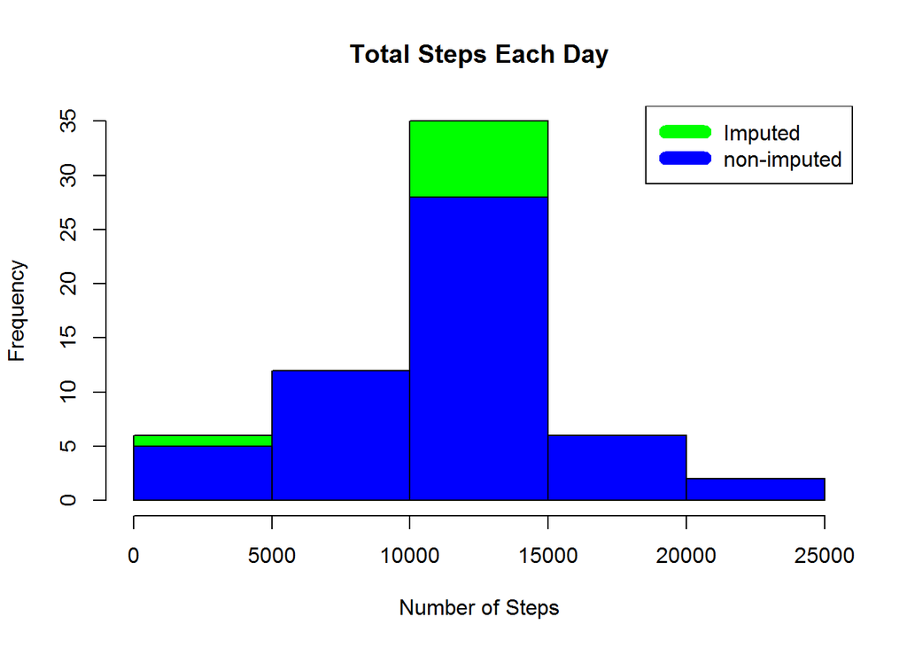

```r
steps_per_day_i <- aggregate(steps ~ date, imputed_data, sum)
hist(steps_per_day_i$steps, main = paste("Total Steps Each Day"), col="green", xlab="Number of Steps")

# Create Histogram to show difference.
hist(steps_per_day$steps, main = paste("Total Steps Each Day"), col="blue", xlab="Number of Steps", add=T)
legend("topright", c("Imputed", "non-imputed"), col=c("green", "blue"), lwd=10)
```

Calculate new mean and median for imputed data.

```r
rmean.i <- mean(steps_per_day_i$steps)
rmean.i
```

```
## [1] 10589.69
```

```r
rmedian.i <- median(steps_per_day_i$steps)
rmedian.i
```

```
## [1] 10766.19
```

Calculate difference between imputed and non-imputed data.

```r
mean_diff <- rmean.i - rmean
mean_diff
```

```
## [1] -176.4949
```

```r
med_diff <- rmedian.i - rmedian
med_diff
```

```
## [1] 1.188679
```

Calculate total difference.

```r
total_diff <- sum(steps_per_day_i$steps) - sum(steps_per_day$steps)
total_diff
```

```
## [1] 75363.32
```

Create a plot to compare and contrast number of steps between the week and weekend. There is a higher peak earlier on weekdays, and more overall activity on weekends.

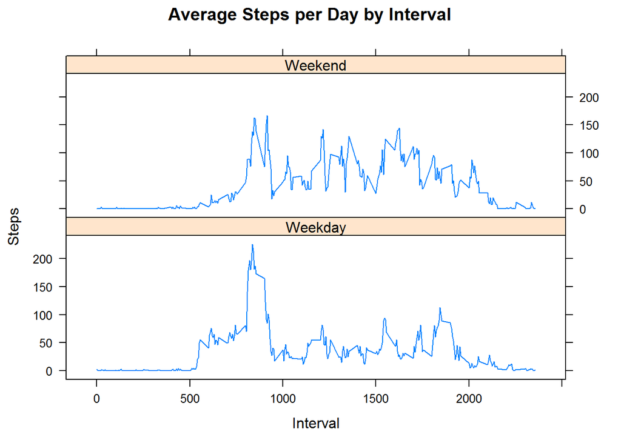

```r
weekdays <- c("Monday", "Tuesday", "Wednesday", "Thursday",
"Friday")
imputed_data$dow = as.factor(ifelse(is.element(weekdays(as.Date(imputed_data$date)),weekdays), "Weekday", "Weekend"))

steps_per_interval_i <- aggregate(steps ~ interval + dow, imputed_data, mean)


library(lattice)

xyplot(steps_per_interval_i$steps ~ steps_per_interval_i$interval|steps_per_interval_i$dow, main="Average Steps per Day by Interval",xlab="Interval", ylab="Steps",layout=c(1,2), type="l")
```